# Practical Machine Learning Course Project

The goal of this project is to examine and predict the effects of contributing variables to the “classe” variable in the training set.

## Uploading Required Packages

I begin this project with uploading the following packages into R:

```r
library(caret)
library(rpart)
```

```r
library(rpart.plot)
library(randomForest)
```

## Importing Data

After downloading data sets from the links provided by Coursera, they have to be read by R:

```r
test <- read.csv("pml-testing.csv", header=T, na.strings = c("NA", "#DIV/0!", ""))
train <- read.csv("pml-training.csv", header=T, na.strings = c("NA", "#DIV/0!", ""))
```

The next step is to look closely at the obtained data:

```r
str(train)
head(train)
str(test)
head(test)
```

## Cleaning Data

To exclude all of variables with at least one “NA” from the data sets, the following codes should yield the desired results:

```r
train2 <- train[, apply(train, 2, function(x) !any(is.na(x)))]
test2 <- test[, apply(test, 2, function(x) !any(is.na(x)))]
```

In addition, columns one to eight can be removed from the data sets:

```r
train3 <- train2 [,-c(1:8)]
test3 <- test2 [,-c(1:8)]
```

## Spliting Data

The next step is to split train data set into two new data sets: training and testing. I used 75% for training data set size and 25% for testing:

```r
set.seed(65478)
inTrain <- createDataPartition(y=train3$classe, p=0.75, list=FALSE)
training  <- train3[inTrain,]
testing  <- train3[-inTrain,]
```

## Modeling

Alright! The data is processed and ready to get analyzed. I will start the data analysis process with fitting a CART model:

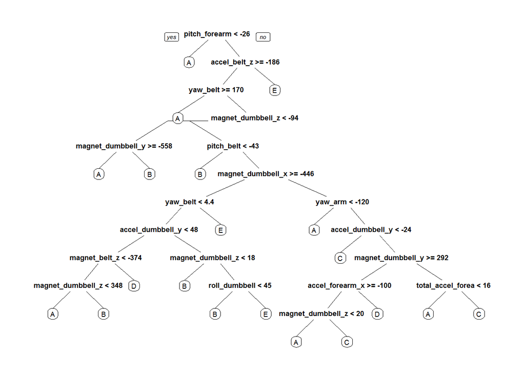

```r
set.seed(654789)
cartmodel <- rpart(classe ~ ., data=training, method="class")
prp(cartmodel)
```

Then, developing a random forest model may be helpful:

```r
set.seed(6547891)
rfmodel <- randomForest(classe ~. , data=training)
```

## Results

To select the best model for this data, it is necessary to run a sensitivity analysis. Taking alook at the prediction rates extracted from both CART and random forests should be useful:

```r
precart <- predict(cartmodel, testing, type = "class")
confusionMatrix(precart, testing$classe)
```

```
## Confusion Matrix and Statistics
##
##           Reference
## Prediction    A    B    C    D    E
##          A 1235  150   20   52   40
##          B   34  492   44   56   27
##          C   26  144  660  175  237
##          D   85   86  105  473   30
##          E   15   77   26   48  567
##
## Overall Statistics
##
##                Accuracy : 0.6988
##                  95% CI : (0.6858, 0.7116)
##     No Information Rate : 0.2845
##     P-Value [Acc > NIR] : < 2.2e-16
##
##                   Kappa : 0.6186
##  Mcnemar's Test P-Value : < 2.2e-16
##
## Statistics by Class:
##
##                      Class: A Class: B Class: C Class: D Class: E
## Sensitivity            0.8853   0.5184   0.7719  0.58831   0.6293
## Specificity            0.9253   0.9593   0.8563  0.92537   0.9585
## Pos Pred Value         0.8250   0.7534   0.5314  0.60719   0.7735
## Neg Pred Value         0.9530   0.8925   0.9468  0.91976   0.9199
## Prevalence             0.2845   0.1935   0.1743  0.16395   0.1837
## Detection Rate         0.2518   0.1003   0.1346  0.09645   0.1156
## Detection Prevalence   0.3053   0.1332   0.2533  0.15885   0.1495
## Balanced Accuracy      0.9053   0.7389   0.8141  0.75684   0.7939
```

```r
prerf <- predict(rfmodel, testing, type = "class")
confusionMatrix(prerf, testing$classe)
```

```
## Confusion Matrix and Statistics
##
##           Reference
## Prediction    A    B    C    D    E
##          A 1395    5    0    0    0
##          B    0  944    4    0    0
##          C    0    0  849    9    0
##          D    0    0    2  794    2
##          E    0    0    0    1  899
##
## Overall Statistics
##
##                Accuracy : 0.9953
##                  95% CI : (0.993, 0.997)
##     No Information Rate : 0.2845
##     P-Value [Acc > NIR] : < 2.2e-16
##
##                   Kappa : 0.9941
##  Mcnemar's Test P-Value : NA
##
## Statistics by Class:
##
##                      Class: A Class: B Class: C Class: D Class: E
## Sensitivity            1.0000   0.9947   0.9930   0.9876   0.9978
## Specificity            0.9986   0.9990   0.9978   0.9990   0.9998
## Pos Pred Value         0.9964   0.9958   0.9895   0.9950   0.9989
## Neg Pred Value         1.0000   0.9987   0.9985   0.9976   0.9995
## Prevalence             0.2845   0.1935   0.1743   0.1639   0.1837
## Detection Rate         0.2845   0.1925   0.1731   0.1619   0.1833
## Detection Prevalence   0.2855   0.1933   0.1750   0.1627   0.1835
## Balanced Accuracy      0.9993   0.9969   0.9954   0.9933   0.9988
```

## Conclusion

Based on the results, the performance of random forests model is great with a 99.53% accuracy. The accuracy for the CART model is 69.88% that is acceptable too. Thus, I will choose the RF model.

## Out-of-Sample Error

Based on the results from random forest model, the out of sample error is 0.0047 (1-0.9953=0.0047) or 0.47%. Pretty Cool!